# Housing mice Notebook

```r
source("utils.R") # for data formatting functions and other useful globals.
require(VIM) # for missingness visualisation.
require(mice) # for mice multiple imputation.
require(lattice) # for mice imputation functions.
require(ordinal) # for clm models.
require(tidyr) # for data frame formatting.
require(viridis) # for python's nice colour palettes
# load data from 2011 and format it via utils.R functions.
data_source<- "data/corrected_US/"
years <- c("2011")
file_names <- get_US_file_names(data_source, years)
data <- get_US_data(file_names)
data <- format_US_housing_data(data)

n_heating_missing <- nrow(data) - sum(complete.cases(data[,c("heating")]))
n_five_missing <- nrow(data) - sum(complete.cases(data[,c("fridge_freezer", "washing_machine", "tumble_dryer", "dishwasher", "microwave")]))
n_six_missing <- nrow(data) - sum(complete.cases(data[,c("fridge_freezer", "washing_machine", "tumble_dryer", "dishwasher", "microwave", "heating")]))
household_vars = c("fridge_freezer",
                   "washing_machine",
                   "tumble_dryer",
                   "dishwasher",
                   "microwave",
                   "heating")
```

Data description demonstrates the six SIPHER7 household variables as well as other variables used in imputation that may indicate missingness. To more clearly demonstrate missingness structure first use aggr plots from VIM.

```
not enough vertical space to display frequencies (too many combinations)
```

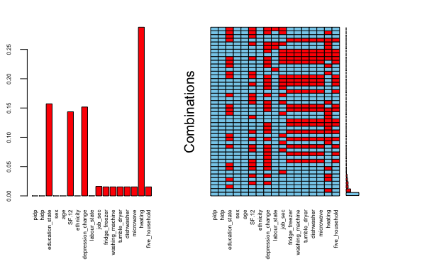

```r
a <- aggr(data, cex.axis=.5, oma=c(5,2,2,5),numbers=T, cex.numbers=0.5) # cex and oma adjustments so all labels show up.
```

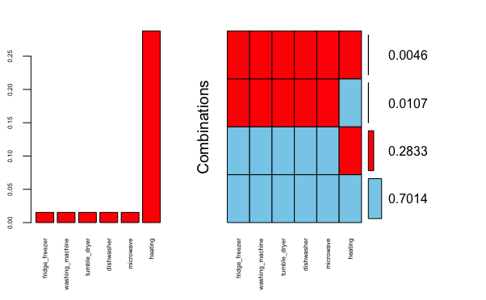

```r
b <- aggr(data[, household_vars], numbers=T, cex.axis=.5, oma=c(5,2,2,5))
```

Since 5 household variables are simultaneous missing it is worth compositing them together and imputing them as one variable https://www.ncbi.nlm.nih.gov/pmc/articles/PMC3074241/pdf/MPR-20-40.pdf. Heating will be imputed separately and then the two variables will be merged into one final SIPHER7 value.

The next part of the imputation strategy is which variables to include in analysis. It is suggested to have an imputation dataset larger than any dataset used in transition probability calibration ensuring any variable that may be indicative of missingness. VIM and MICE packages have good visualisation tools to represent this. These tools quantify distributional differences of variables between those missing houshold values and those not.

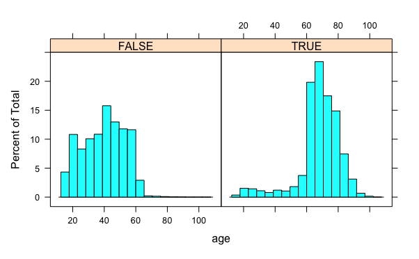

```r
is_missing_heating <- is.na(data$heating)
is_missing_five <- is.na(data$fridge_freezer)
histogram(~age|is_missing_heating, data)
```

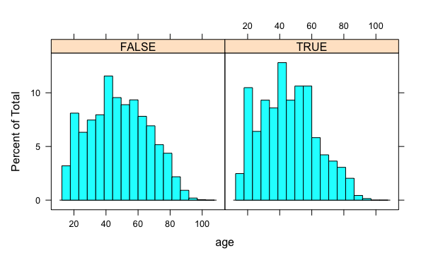

```r
histogram(~age|is_missing_five, data)
```

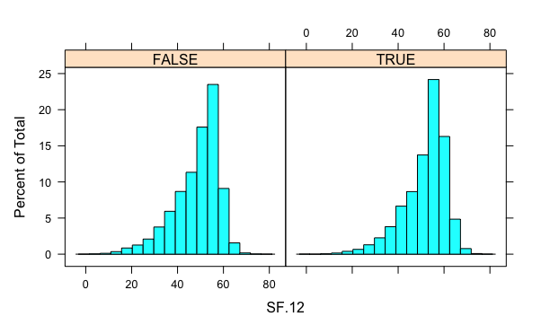

```r
histogram(~SF.12|is_missing_heating, data)
```

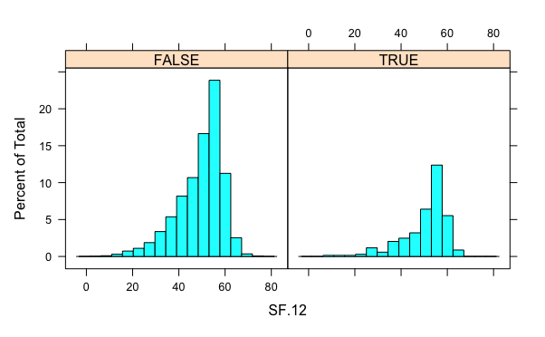

```r
histogram(~SF.12|is_missing_five, data)
```

```
[1] "ethnicity"
[1] "heating"
```

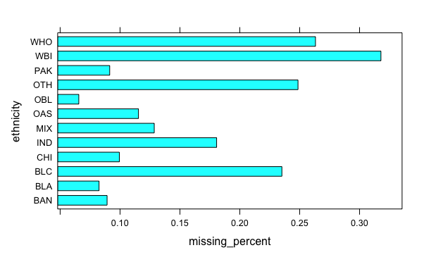

```r
# needs better scaling for low % missing data
# scaling works with ylim change but ticks needs relabelling.
#spineMiss(data[, c("job_sec", "heating")], col = c(blue, orange), ylim=c(0, 0.2))
#spineMiss(data[, c("job_sec", "fridge_freezer")], col = c(blue, orange), )

missing_barchart <- function(data, v1, v2){
  print(v1)
  print(v2)
  missing_table <- table(data[,v1], is.na(data[,v2]))
  # not guaranteed to be on these rows. needs forcing to correct labels somehow.
  missing_percent <- missing_table[,2]/(missing_table[,1]+missing_table[,2])
  barchart(missing_percent, ylab = v1)
}
missing_barchart(data, "ethnicity", "heating")
```

```
[1] "ethnicity"
[1] "heating"
```

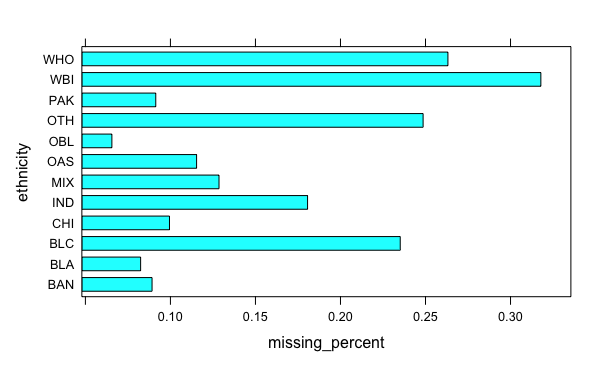

```r
missing_barchart(data, "ethnicity", "heating")
```

```
[1] "depression_change"
[1] "heating"
```

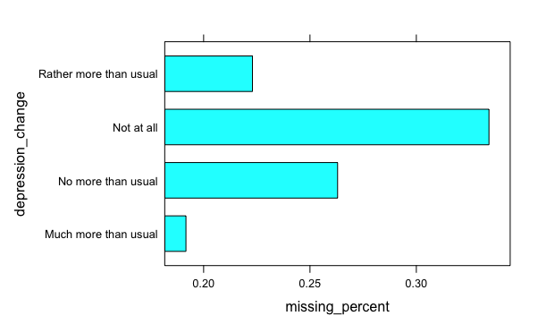

```r
missing_barchart(data, "depression_change", "heating")
```

```
[1] "education_state"
[1] "heating"
```

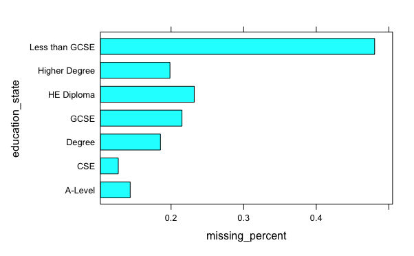

```r
missing_barchart(data, "education_state", "heating")
```

```
[1] "labour_state"
[1] "heating"
```

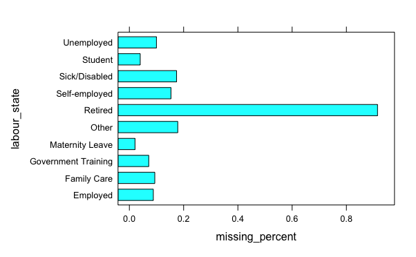

```r
missing_barchart(data, "labour_state", "heating")
```

```
[1] "sex"
[1] "heating"
```

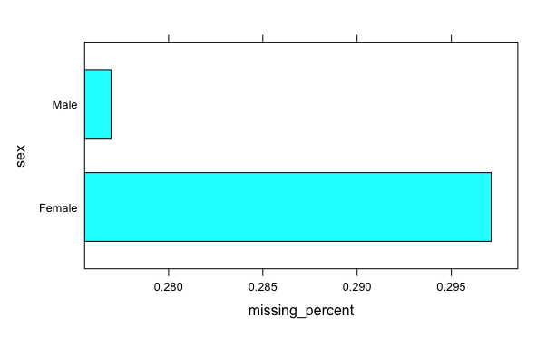

```r
missing_barchart(data, "sex", "heating")
```

```
[1] "job_sec"
[1] "heating"
```

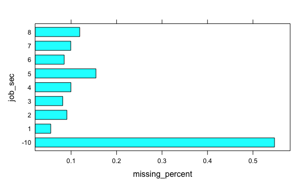

```r
missing_barchart(data, "job_sec", "heating")
```

Can apply these plots to all variables used in imputation of heating and five others respectively.

```r
imp_columns <- c("five_household", "heating", "labour_state", "education_state",
                 "sex", "job_sec", "ethnicity", "age", "SF.12")
house_mice <- mice(data = data[,imp_columns],
                 m = 20, maxit = 20, seed = 500,
                 remove.collinear=T)
```

```
Number of logged events: 4
```

```r
print(summary(complete(house_mice)[,c("five_household","heating")]))
```

```
 five_household     heating
 Min.   :0.000   Min.   :-3.0000
 1st Qu.:3.000   1st Qu.: 1.0000
 Median :4.000   Median : 1.0000
 Mean   :3.968   Mean   : 0.9186
 3rd Qu.:5.000   3rd Qu.: 1.0000
 Max.   :5.000   Max.   : 1.0000
```

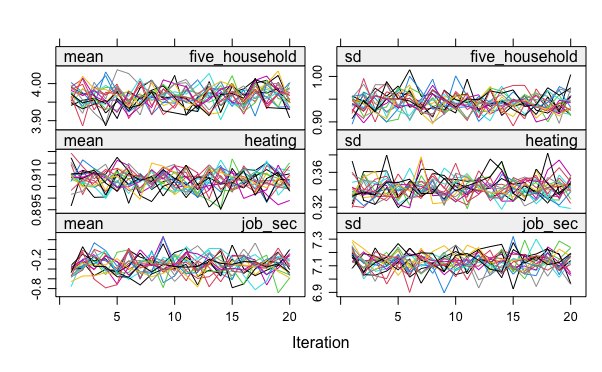

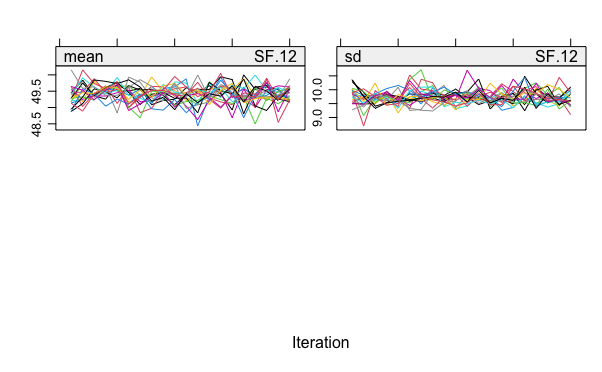

```r
plot(house_mice)
```

```r
data2<- complete(house_mice)
data2 <- tidyr::drop_na(data2)
# format final housing composite. If they have no appliances assign 0.
# any up to 5 assign 1.
# all assign 2.
data2$housing <- rowSums(data2[, c("five_household", "heating")])
data2[which(data2$housing <= 3), "housing"] <- 0
data2[which(data2$housing <= 4 & data2$housing > 3), "housing"] <- 1
data2[which(data2$housing >= 5), "housing"] <- 2

data2$housing <- factor(data2$housing, levels = c(0,1,2))
n <- nrow(data2)
set.seed(88)
Inx <- sample(n, 0.8*n)
train<-data2[Inx,]
test<-data2[-Inx,]
y <- test$housing
test <- subset(test, select= - housing)

formula <- "housing ~ factor(sex) +
                      age +
                      SF.12 +
                      factor(labour_state) +
                      factor(job_sec)"
housing.clmm <- clm(housing ~ factor(sex) +
                                age +
                                SF.12 +
                                factor(labour_state) +
                                factor(job_sec) +
                                factor(ethnicity),
                                data= train[complete.cases(train),],
                                link = "logit",
                                threshold = "flexible",
                                Hess=T)
```

[output not shown]

```r
print(summary(housing.clmm))
```

```
formula:
housing ~ factor(sex) + age + SF.12 + factor(labour_state) + factor(job_sec) + factor(ethnicity)
data:    train[complete.cases(train), ]
```

| link | threshold | nobs | logLik | AIC | niter | max.grad | cond.H |
| --- | --- | --- | --- | --- | --- | --- | --- |
| logit | flexible | 90746 | -71708.85 | 143483.69 | 5(0) | 4.80e-07 | 4.3e+06 |

```
Coefficients:
                                          Estimate Std. Error z value Pr(>|z|)
factor(sex)Male                         -0.0258130  0.0150041  -1.720 0.085361
age                                     -0.0022650  0.0006422  -3.527 0.000421
SF.12                                    0.0133378  0.0007264  18.362  < 2e-16
factor(labour_state)Family Care          0.0973130  0.0543693   1.790 0.073478
factor(labour_state)Government Training -1.2415940  0.2072331  -5.991 2.08e-09
factor(labour_state)Maternity Leave     -0.2143154  0.0956205  -2.241 0.025006
factor(labour_state)Other               -0.2361008  0.1011979  -2.333 0.019645
factor(labour_state)Retired             -0.1450960  0.0521727  -2.781 0.005418
factor(labour_state)Self-employed        0.0719076  0.0438697   1.639 0.101189
factor(labour_state)Sick/Disabled       -0.5039444  0.0587002  -8.585  < 2e-16
factor(labour_state)Student              0.3305542  0.0485328   6.811 9.70e-12
factor(labour_state)Unemployed          -0.4257756  0.0540068  -7.884 3.18e-15
factor(job_sec)1                         1.0788692  0.0720835  14.967  < 2e-16
factor(job_sec)2                         0.6377678  0.0579965  10.997  < 2e-16
factor(job_sec)3                         0.4410322  0.0495040   8.909  < 2e-16
factor(job_sec)4                         0.4022802  0.0527406   7.628 2.39e-14
factor(job_sec)5                         0.3487061  0.0629608   5.538 3.05e-08
factor(job_sec)6                         0.2374697  0.0576570   4.119 3.81e-05
factor(job_sec)7                         0.1520238  0.0483382   3.145 0.001661
factor(job_sec)8                         0.0900452  0.0523723   1.719 0.085555
factor(ethnicity)BLA                     0.0306670  0.0570202   0.538 0.590696
factor(ethnicity)BLC                     0.8948129  0.0615143  14.546  < 2e-16
factor(ethnicity)CHI                     0.4050314  0.1002188   4.041 5.31e-05
factor(ethnicity)IND                     1.2046302  0.0543498  22.164  < 2e-16
factor(ethnicity)MIX                     0.9755367  0.0642277  15.189  < 2e-16
factor(ethnicity)OAS                     0.4899867  0.0640488   7.650 2.01e-14
factor(ethnicity)OBL                     0.6942950  0.1695912   4.094 4.24e-05
factor(ethnicity)OTH                     1.3312178  0.1157434  11.501  < 2e-16
factor(ethnicity)PAK                     0.5472036  0.0537010  10.190  < 2e-16
factor(ethnicity)WBI                     1.6783508  0.0422251  39.748  < 2e-16
factor(ethnicity)WHO                     1.2583632  0.0535490  23.499  < 2e-16

factor(sex)Male                         .
age                                     ***
SF.12                                   ***
factor(labour_state)Family Care         .
factor(labour_state)Government Training ***
factor(labour_state)Maternity Leave     *
```

[output cut: 17 more lines]

```
factor(ethnicity)IND                    ***
factor(ethnicity)MIX                    ***
factor(ethnicity)OAS                    ***
factor(ethnicity)OBL                    ***
factor(ethnicity)OTH                    ***
factor(ethnicity)PAK                    ***
factor(ethnicity)WBI                    ***
factor(ethnicity)WHO                    ***
---
Signif. codes:  0 ‘***’ 0.001 ‘**’ 0.01 ‘*’ 0.05 ‘.’ 0.1 ‘ ’ 1

Threshold coefficients:
    Estimate Std. Error z value
0|1 -0.39468    0.07437  -5.307
1|2  1.50945    0.07445  20.275
```

```r
prs<- 1 - logLik(housing.clmm)/logLik(clm2(housing ~ 1,data= train))
print(prs)
```

```
'log Lik.' 0.04853137 (df=33)
```

```r
# remove housing column or predict function doesnt give full multinom probabilities.

preds <- predict(housing.clmm, test)$fit
markers <-as.numeric(as.character(factor(y, labels = c(0, 10, 25))))
markers <- as.integer(markers)
colours <-cividis(3)
v_colours <- factor(y, labels = cividis(3))

table(y, predict(housing.clmm, test, type="class")$fit)
```

```
y       0     1     2
  0     0  1801    39
  1     2 13002   509
  2     0  6786   548
```

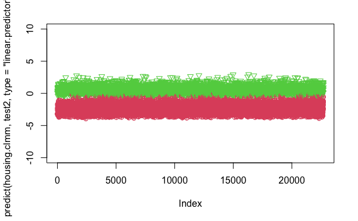

```r
test2<-test
test2$housing <- y
#par(mfrow(c(2,1)))
plot(predict(housing.clmm, test2, type="linear.predictor")$eta2, ylim=c(-10, 10)
, col=v_colours, pch=markers)
```

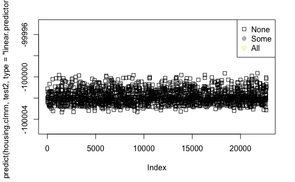

```r
plot(predict(housing.clmm, test2, type="linear.predictor")$eta2, ylim=c(-100005, -99995)
, col=v_colours, pch=markers)
legend("topright", legend=c("None", "Some", "All"), col = colours, pch =c(0, 10, 25))
```

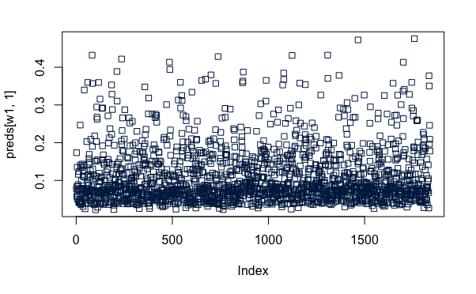

```r
w1 <- which(y == 0)
plot(preds[w1, 1], col =  colours[1], pch=0)#dev.off()
```

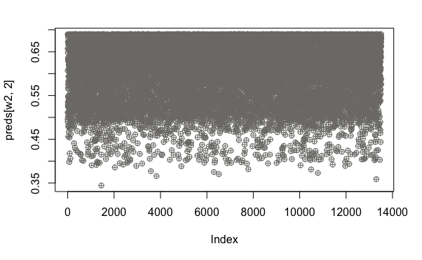

```r
w2 <- which(y == 1)
plot(preds[w2, 2], col =  colours[2], pch=10)#dev.off()
```

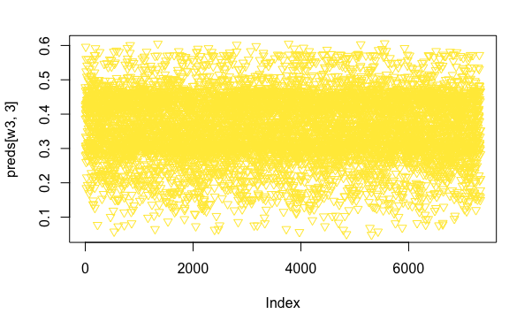

```r
w3 <- which(y == 2)
plot(preds[w3, 3], col =  colours[3], pch=25)#dev.off()
```